# Is Red Coloration in Chrosomus erythrogaster an Honest Signal? Advanced Data Analytics

Austin Peay State University

```r
leaflet() %>%
  setView(-86.854396, 36.26361 , zoom = 16) %>% #lat-long of the place of interest
  addTiles() %>%
  addProviderTiles('Esri.WorldImagery') %>%
  addMarkers(-86.854396, 36.26361 , popup = "Dry Fork, Whites Creek System")
```

[interactive chart not shown]

```r
leaflet() %>%
  setView(-87.287965, 36.499277 , zoom = 16) %>% #lat-long of the place of interest
  addTiles() %>%
  addProviderTiles('Esri.WorldImagery') %>%
  addMarkers(-87.287965, 36.499277 , popup = "Rotary Park, Wall Branch Creek System")
```

[interactive chart not shown]

```r
model10 <- lm(GSI_Value~Chroma_Gill + Sat_Gill, data = Thesis_Data)
model18 <- lm(GSI_Value~Chroma_Gill + Tint_Gill, data = Thesis_Data)
```

```r
anova(model18)
```

```
## Analysis of Variance Table
##
## Response: GSI_Value
##             Df Sum Sq Mean Sq F value Pr(>F)
## Chroma_Gill  1   7.63   7.634  0.3669 0.5496
## Tint_Gill    1  72.59  72.588  3.4884 0.0723 .
## Residuals   28 582.63  20.808
## ---
## Signif. codes:  0 '***' 0.001 '**' 0.01 '*' 0.05 '.' 0.1 ' ' 1
```

```r
summary(model18)
```

```
##
## Call:
## lm(formula = GSI_Value ~ Chroma_Gill + Tint_Gill, data = Thesis_Data)
##
## Residuals:
##     Min      1Q  Median      3Q     Max
## -6.9132 -2.7457 -0.8285  0.6398 15.8374
##
## Coefficients:
##             Estimate Std. Error t value Pr(>|t|)
## (Intercept)  4.96423    1.71268   2.899  0.00721 **
## Chroma_Gill  0.43124    0.21971   1.963  0.05967 .
## Tint_Gill    0.10244    0.05485   1.868  0.07230 .
## ---
## Signif. codes:  0 '***' 0.001 '**' 0.01 '*' 0.05 '.' 0.1 ' ' 1
##
## Residual standard error: 4.562 on 28 degrees of freedom
## Multiple R-squared:  0.121,  Adjusted R-squared:  0.05824
## F-statistic: 1.928 on 2 and 28 DF,  p-value: 0.1643
```

```r
anova(model10)
```

```
## Analysis of Variance Table
##
## Response: GSI_Value
##             Df Sum Sq Mean Sq F value  Pr(>F)
## Chroma_Gill  1   7.63   7.634  0.3735 0.54602
## Sat_Gill     1  82.96  82.956  4.0589 0.05363 .
## Residuals   28 572.26  20.438
## ---
## Signif. codes:  0 '***' 0.001 '**' 0.01 '*' 0.05 '.' 0.1 ' ' 1
```

```r
summary(model10)
```

```
##
## Call:
## lm(formula = GSI_Value ~ Chroma_Gill + Sat_Gill, data = Thesis_Data)
##
## Residuals:
##     Min      1Q  Median      3Q     Max
## -7.3841 -2.6634 -0.9783  0.6944 15.6669
##
## Coefficients:
##             Estimate Std. Error t value Pr(>|t|)
## (Intercept)   5.5019     1.7589   3.128  0.00408 **
## Chroma_Gill   0.4852     0.2305   2.105  0.04442 *
## Sat_Gill    -12.0386     5.9755  -2.015  0.05363 .
## ---
## Signif. codes:  0 '***' 0.001 '**' 0.01 '*' 0.05 '.' 0.1 ' ' 1
##
## Residual standard error: 4.521 on 28 degrees of freedom
## Multiple R-squared:  0.1367, Adjusted R-squared:  0.075
## F-statistic: 2.216 on 2 and 28 DF,  p-value: 0.1278
```

```r
out.put1<-model.sel(model10, model18)
out.put1
```

```
## Model selection table
##         (Int) Chr_Gll Sat_Gll Tnt_Gll             family df  logLik  AICc delta
## model10 5.502  0.4852  -12.04         gaussian(identity)  4 -89.179 187.9  0.00
## model18 4.964  0.4312          0.1024 gaussian(identity)  4 -89.457 188.5  0.56
##         weight
## model10  0.569
## model18  0.431
## Models ranked by AICc(x)
```

Low delta <2 for both. Model 10 which includes both Chroma_Gill and Saturation_Gill is about 1.32 times more likely than model 18 which contains Chroma_Gill and Tint_Gill.

```r
importance(out.put1)
```

```
##                      Chroma_Gill Sat_Gill Tint_Gill
## Sum of weights:      1.00        0.57     0.43
## N containing models:    2           1        1
```

Here are the importance values of each of the variables used in the model selection.Chroma_Gill carrying most of that weight.

Now to average the models using the lm from out.put1:

```r
model.avg(out.put1, revised.var = TRUE)
```

```
##
## Call:
## model.avg(object = out.put1, revised.var = TRUE)
##
## Component models:
## '12' '13'
##
## Coefficients:
##        (Intercept) Chroma_Gill   Sat_Gill  Tint_Gill
## full      5.270226    0.461975  -6.851555 0.04413711
## subset    5.270226    0.461975 -12.038597 0.10243775
```

```r
summary(model.avg(out.put1))
```

```
##
## Call:
## model.avg(object = out.put1)
##
## Component model call:
## lm(formula = <2 unique values>, data = Thesis_Data)
##
## Component models:
##    df logLik   AICc delta weight
## 12  4 -89.18 187.90  0.00   0.57
## 13  4 -89.46 188.45  0.56   0.43
##
## Term codes:
## Chroma_Gill    Sat_Gill   Tint_Gill
##           1           2           3
##
## Model-averaged coefficients:
## (full average)
##             Estimate Std. Error Adjusted SE z value Pr(>|z|)
## (Intercept)  5.27023    1.75942     1.83703   2.869  0.00412 **
## Chroma_Gill  0.46198    0.22752     0.23764   1.944  0.05190 .
## Sat_Gill    -6.85155    7.47401     7.59843   0.902  0.36721
## Tint_Gill    0.04414    0.06220     0.06316   0.699  0.48465
##
## (conditional average)
##              Estimate Std. Error Adjusted SE z value Pr(>|z|)
## (Intercept)   5.27023    1.75942     1.83703   2.869  0.00412 **
## Chroma_Gill   0.46198    0.22752     0.23764   1.944  0.05190 .
## Sat_Gill    -12.03860    5.97545     6.24510   1.928  0.05389 .
## Tint_Gill     0.10244    0.05485     0.05732   1.787  0.07392 .
## ---
## Signif. codes:  0 '***' 0.001 '**' 0.01 '*' 0.05 '.' 0.1 ' ' 1
```

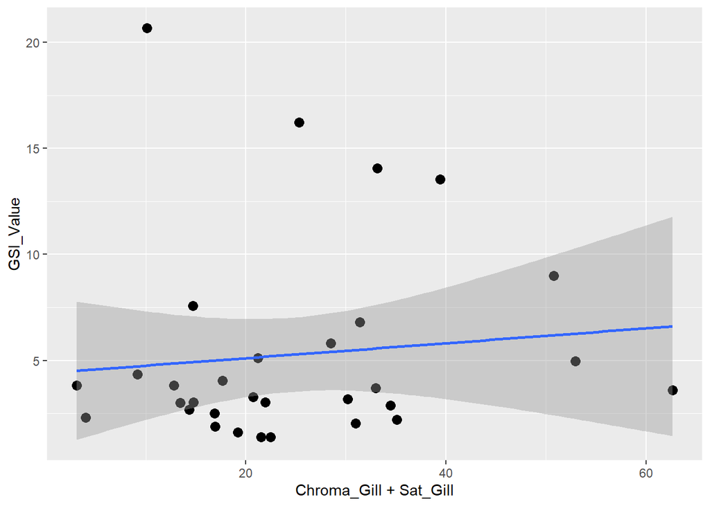

```r
p1c <- ggplot(Thesis_Data, aes(Chroma_Gill + Sat_Gill, GSI_Value)) +
  geom_point(size=3) +
  geom_smooth(method="lm")

p1c
```

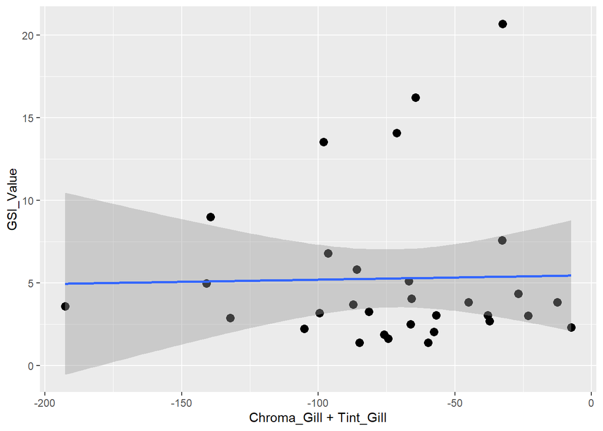

```r
p1c <- ggplot(Thesis_Data, aes(Chroma_Gill + Tint_Gill, GSI_Value)) +
  geom_point(size=3) +
  geom_smooth(method="lm")

p1c
```

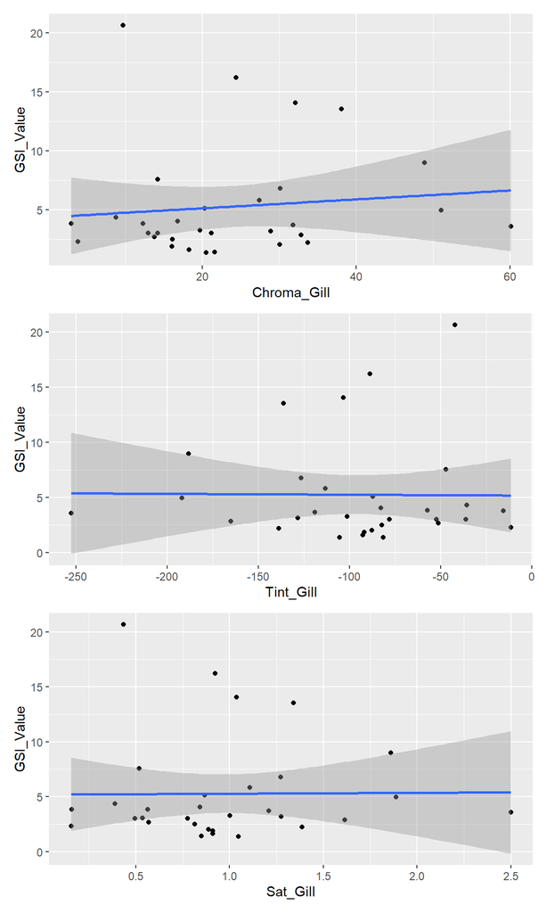

```r
wchroma <- ggplot(Thesis_Data, aes(Chroma_Gill, GSI_Value)) +
  geom_point() +
  geom_smooth(method="lm")


wtint <- ggplot(Thesis_Data, aes(Tint_Gill, GSI_Value)) +
  geom_point() +
  geom_smooth(method="lm")

wsat <- ggplot(Thesis_Data, aes(Sat_Gill, GSI_Value)) +
  geom_point() +
  geom_smooth(method="lm")

wchroma / wtint / wsat
```

Binary Data Below….

```r
Site_GSI <- read.csv("Site_GSI.csv")
```

```r
fit.1 <- glm(Site_Location~GSI_Value, data=Site_GSI, binomial(link="logit"))

anova(fit.1)
```

```
## Analysis of Deviance Table
##
## Model: binomial, link: logit
##
## Response: Site_Location
##
## Terms added sequentially (first to last)
##
##
##           Df Deviance Resid. Df Resid. Dev
## NULL                         30     42.943
## GSI_Value  1   1.6818        29     41.261
```

```r
summary(fit.1)
```

```
##
## Call:
## glm(formula = Site_Location ~ GSI_Value, family = binomial(link = "logit"),
##     data = Site_GSI)
##
## Deviance Residuals:
##     Min       1Q   Median       3Q      Max
## -1.3260  -1.2254  -0.5553   1.1255   1.3946
##
## Coefficients:
##             Estimate Std. Error z value Pr(>|z|)
## (Intercept)  0.49833    0.57816   0.862    0.389
## GSI_Value   -0.11082    0.09331  -1.188    0.235
##
## (Dispersion parameter for binomial family taken to be 1)
##
##     Null deviance: 42.943  on 30  degrees of freedom
## Residual deviance: 41.261  on 29  degrees of freedom
## AIC: 45.261
##
## Number of Fisher Scoring iterations: 4
```

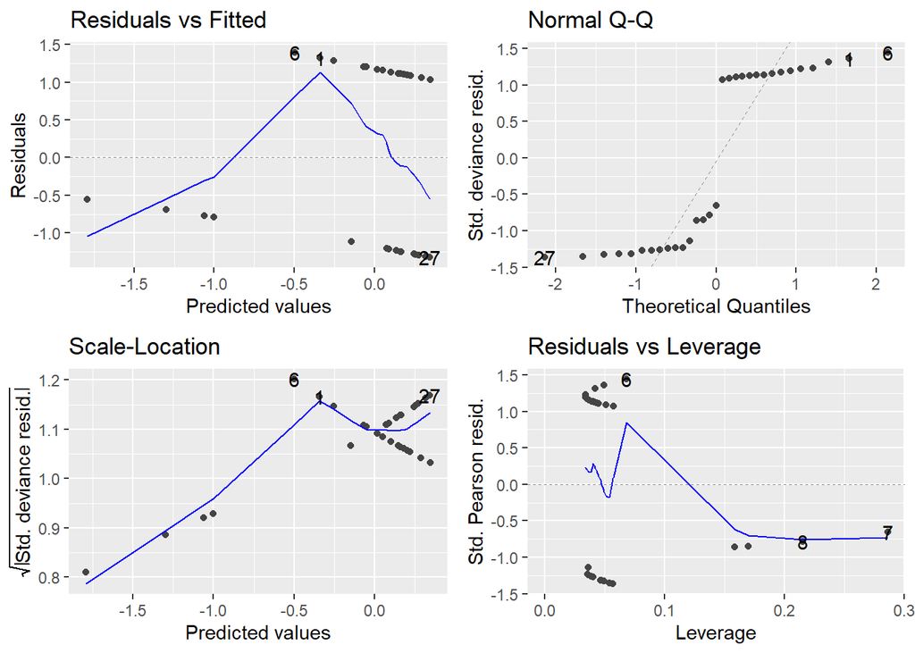

```r
autoplot(fit.1)
```

library(arm)

```r
library(arm)
```

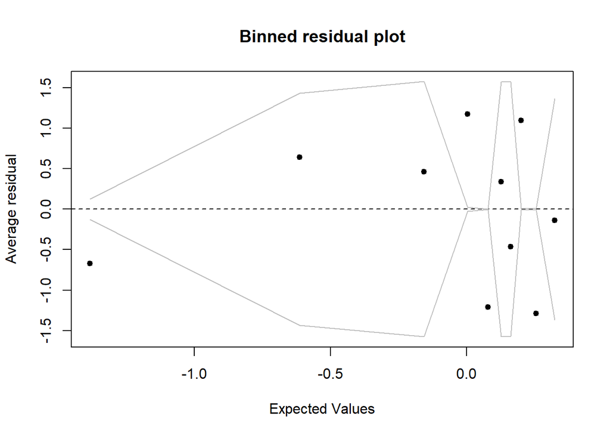

```r
x <- predict(fit.1)
y <- resid(fit.1)
binnedplot(x, y)
```

#The results of the binnedplot, show that binned residuals of this data do not present good binary data. #The binned residual plot is used to view points that fall into +/- 2 standard errors; ~95% of the binned residuals.

```r
coef(fit.1)
```

```
## (Intercept)   GSI_Value
##   0.4983295  -0.1108241
```

```r
confint(fit.1)
```

```
##                  2.5 %     97.5 %
## (Intercept) -0.6070965 1.70345833
## GSI_Value   -0.3361693 0.05272776
```

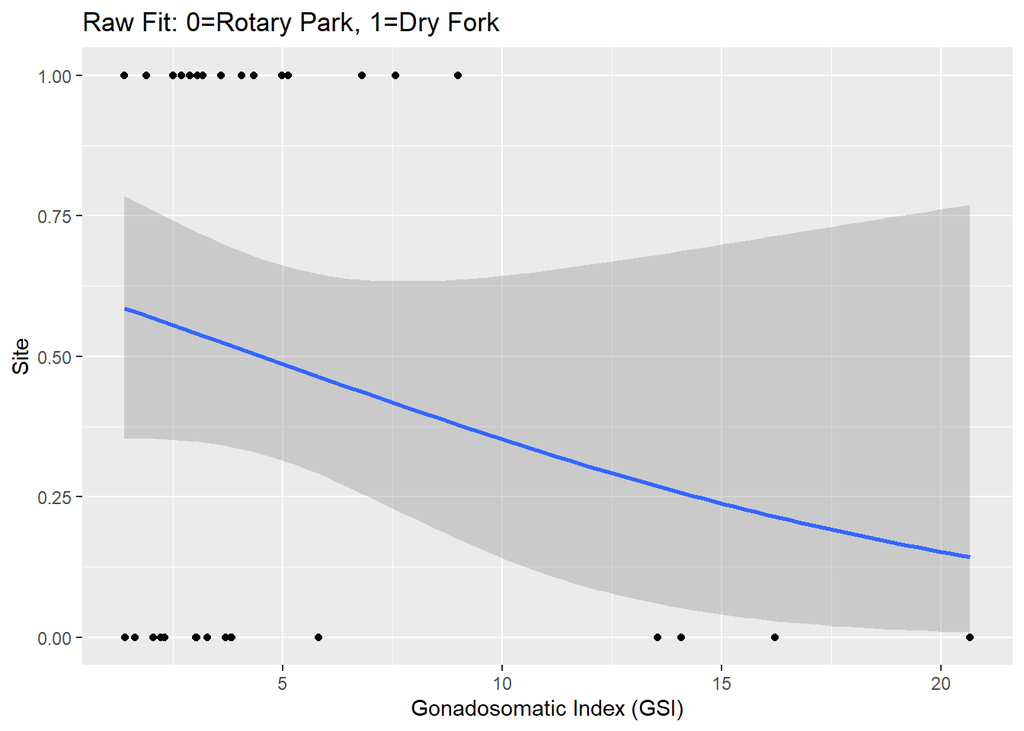

```r
ggplot(Site_GSI, aes(GSI_Value,Site_Location)) +
  geom_point() +
  geom_smooth(method="glm", method.args=list(family="binomial"(link="logit"))) +
  xlab ("Gonadosomatic Index (GSI)") +
  ylab ("Site") +
  labs (title="Raw Fit: 0=Rotary Park, 1=Dry Fork")
```

```r
Site_BCF <- read.csv("Site_BCF.csv")
```

```r
fit.2 <- glm(Site_Location~Body_Condition_Factor, data=Site_BCF, binomial(link="logit"))

anova(fit.2)
```

```
## Analysis of Deviance Table
##
## Model: binomial, link: logit
##
## Response: Site_Location
##
## Terms added sequentially (first to last)
##
##
##                       Df Deviance Resid. Df Resid. Dev
## NULL                                     30     42.943
## Body_Condition_Factor  1   2.4488        29     40.494
```

```r
summary(fit.2)
```

```
##
## Call:
## glm(formula = Site_Location ~ Body_Condition_Factor, family = binomial(link = "logit"),
##     data = Site_BCF)
##
## Deviance Residuals:
##     Min       1Q   Median       3Q      Max
## -1.6788  -1.0549  -0.7832   1.1923   1.4587
##
## Coefficients:
##                       Estimate Std. Error z value Pr(>|z|)
## (Intercept)             -5.844      3.877  -1.508    0.132
## Body_Condition_Factor    7.442      4.968   1.498    0.134
##
## (Dispersion parameter for binomial family taken to be 1)
##
##     Null deviance: 42.943  on 30  degrees of freedom
## Residual deviance: 40.494  on 29  degrees of freedom
## AIC: 44.494
##
## Number of Fisher Scoring iterations: 4
```

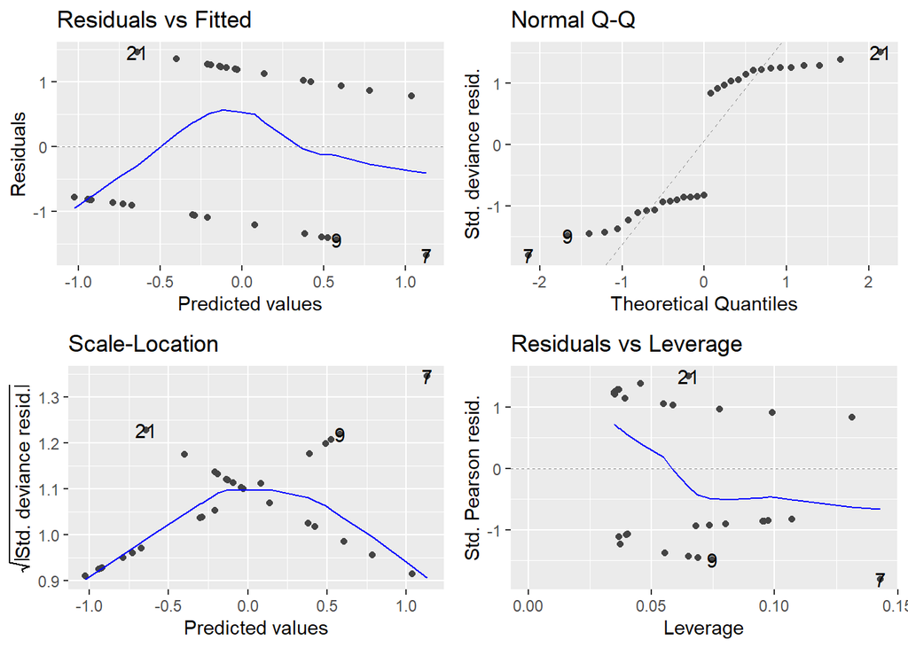

```r
autoplot(fit.2)
```

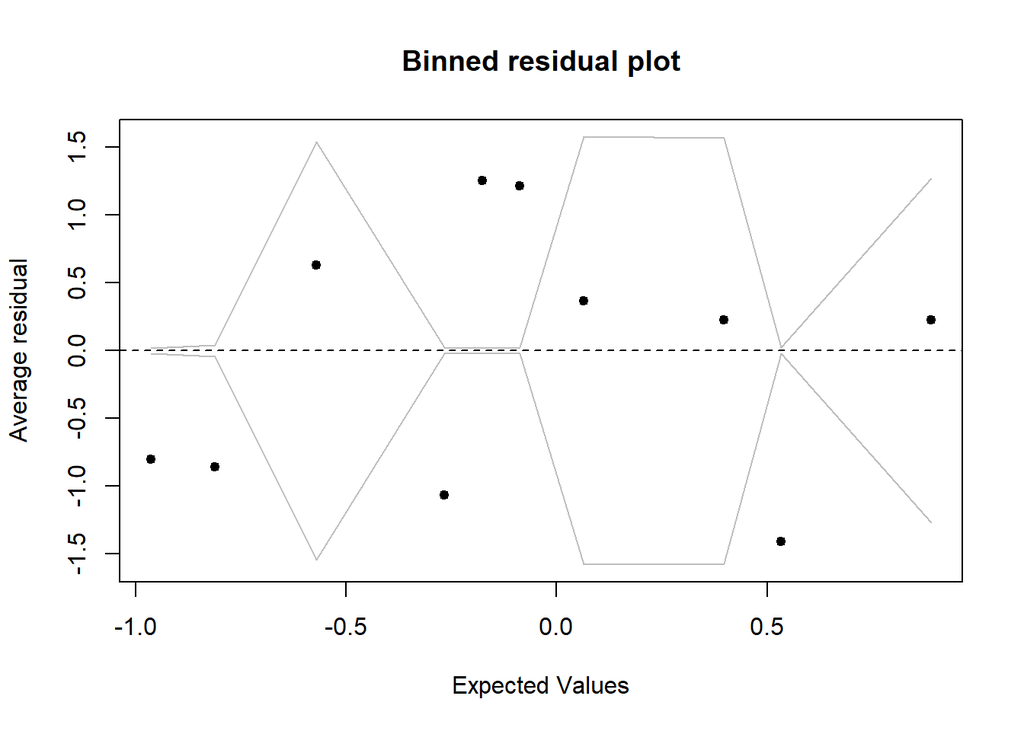

```r
x <- predict(fit.2)
y <- resid(fit.2)
binnedplot(x, y)
```

```r
coef(fit.2)
```

```
##           (Intercept) Body_Condition_Factor
##             -5.844432              7.442381
```

```r
confint(fit.2)
```

```
##                            2.5 %    97.5 %
## (Intercept)           -14.169776  1.383205
## Body_Condition_Factor  -1.819804 18.114250
```

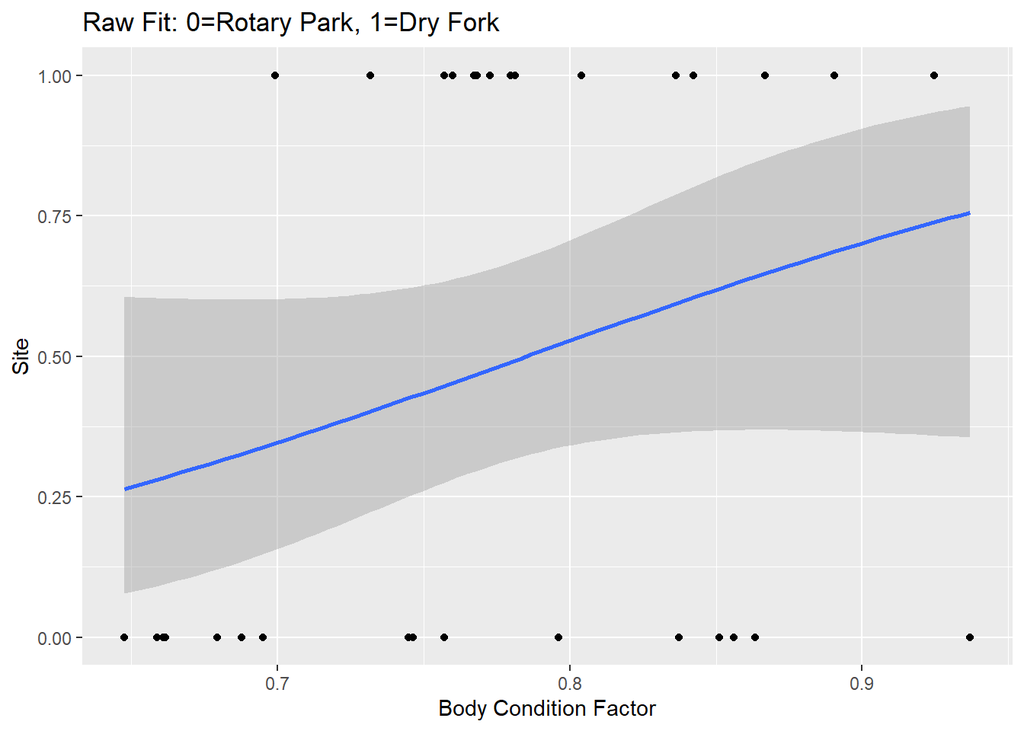

```r
ggplot(Site_BCF, aes(Body_Condition_Factor,Site_Location)) +
  geom_point() +
  geom_smooth(method="glm", method.args=list(family="binomial"(link="logit"))) +
  xlab ("Body Condition Factor") +
  ylab ("Site") +
  labs (title="Raw Fit: 0=Rotary Park, 1=Dry Fork")
```

```r
Season_GSI <- read.csv("Season_GSI.csv")
```

```r
fit.3 <- glm(Season_Collected~GSI_Value, data=Season_GSI, binomial(link="logit"))
anova(fit.3)
```

```
## Analysis of Deviance Table
##
## Model: binomial, link: logit
##
## Response: Season_Collected
##
## Terms added sequentially (first to last)
##
##
##           Df Deviance Resid. Df Resid. Dev
## NULL                         30     42.943
## GSI_Value  1   11.121        29     31.822
```

```r
summary(fit.3)
```

```
##
## Call:
## glm(formula = Season_Collected ~ GSI_Value, family = binomial(link = "logit"),
##     data = Season_GSI)
##
## Deviance Residuals:
##      Min        1Q    Median        3Q       Max
## -1.46646  -0.93314   0.01081   0.85743   1.68542
##
## Coefficients:
##             Estimate Std. Error z value Pr(>|z|)
## (Intercept)  -2.3364     1.1061  -2.112   0.0347 *
## GSI_Value     0.5848     0.2915   2.006   0.0449 *
## ---
## Signif. codes:  0 '***' 0.001 '**' 0.01 '*' 0.05 '.' 0.1 ' ' 1
##
## (Dispersion parameter for binomial family taken to be 1)
##
##     Null deviance: 42.943  on 30  degrees of freedom
## Residual deviance: 31.822  on 29  degrees of freedom
## AIC: 35.822
##
## Number of Fisher Scoring iterations: 6
```

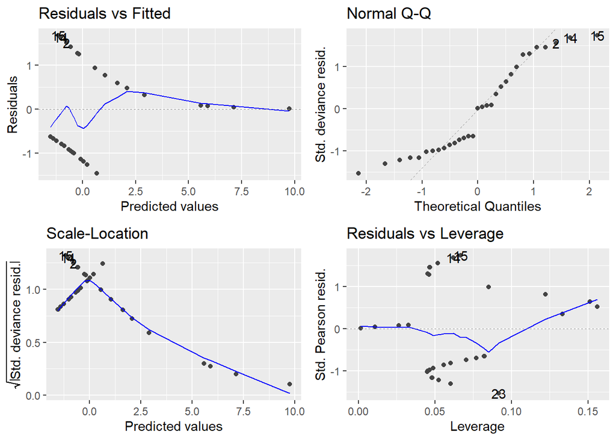

```r
autoplot(fit.3)
```

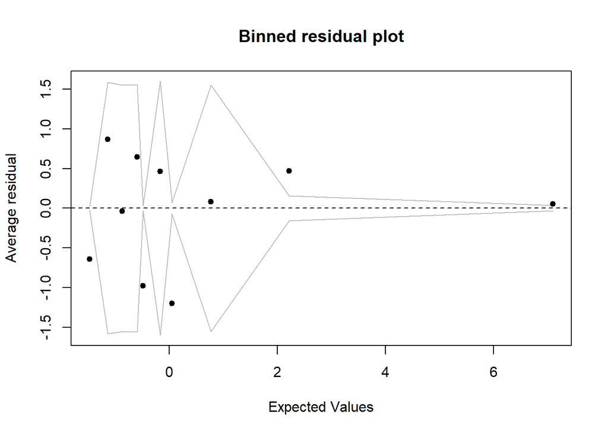

```r
x <- predict(fit.3)
y <- resid(fit.3)
binnedplot(x, y)
```

```r
coef(fit.3)
```

```
## (Intercept)   GSI_Value
##  -2.3363968   0.5847971
```

```r
confint(fit.3)
```

```
##                  2.5 %     97.5 %
## (Intercept) -4.9189269 -0.5231682
## GSI_Value    0.1600218  1.2964211
```

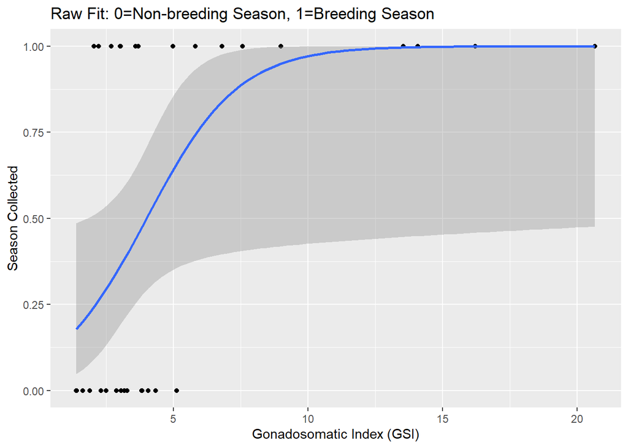

```r
ggplot(Season_GSI, aes(GSI_Value,Season_Collected)) +
  geom_point() +
  geom_smooth(method="glm", method.args=list(family="binomial"(link="logit"))) +
  xlab ("Gonadosomatic Index (GSI)") +
  ylab ("Season Collected") +
  labs (title="Raw Fit: 0=Non-breeding Season, 1=Breeding Season")
```

```r
invlogit <- function(x) {1 / ( 1+exp(-x) ) }
invlogit(coef(fit.3))
```

```
## (Intercept)   GSI_Value
##  0.08815312  0.64217048
```

```r
Season_BCF <- read.csv("Season_BCF.csv")
```

```r
fit.4 <- glm(Season_Collected~Body_Condition_Factor, data=Season_BCF, binomial(link="logit"))

anova(fit.4)
```

```
## Analysis of Deviance Table
##
## Model: binomial, link: logit
##
## Response: Season_Collected
##
## Terms added sequentially (first to last)
##
##
##                       Df Deviance Resid. Df Resid. Dev
## NULL                                     30     42.943
## Body_Condition_Factor  1   5.1768        29     37.766
```

```r
summary(fit.4)
```

```
##
## Call:
## glm(formula = Season_Collected ~ Body_Condition_Factor, family = binomial(link = "logit"),
##     data = Season_BCF)
##
## Deviance Residuals:
##     Min       1Q   Median       3Q      Max
## -1.9688  -1.0623   0.5223   0.9401   1.7943
##
## Coefficients:
##                       Estimate Std. Error z value Pr(>|z|)
## (Intercept)             -8.795      4.293  -2.048   0.0405 *
## Body_Condition_Factor   11.439      5.533   2.067   0.0387 *
## ---
## Signif. codes:  0 '***' 0.001 '**' 0.01 '*' 0.05 '.' 0.1 ' ' 1
##
## (Dispersion parameter for binomial family taken to be 1)
##
##     Null deviance: 42.943  on 30  degrees of freedom
## Residual deviance: 37.766  on 29  degrees of freedom
## AIC: 41.766
##
## Number of Fisher Scoring iterations: 4
```

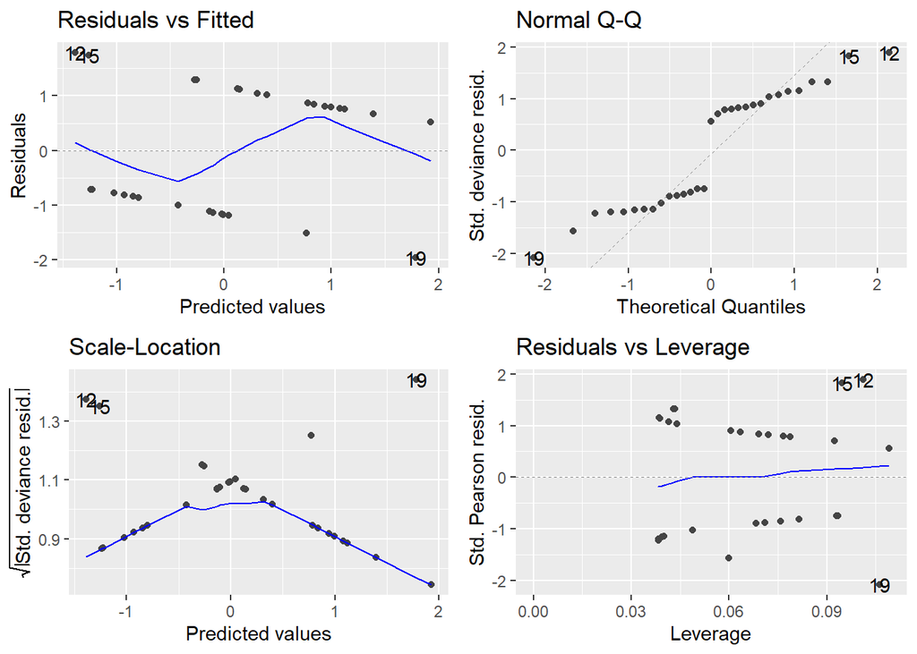

```r
autoplot(fit.4)
```

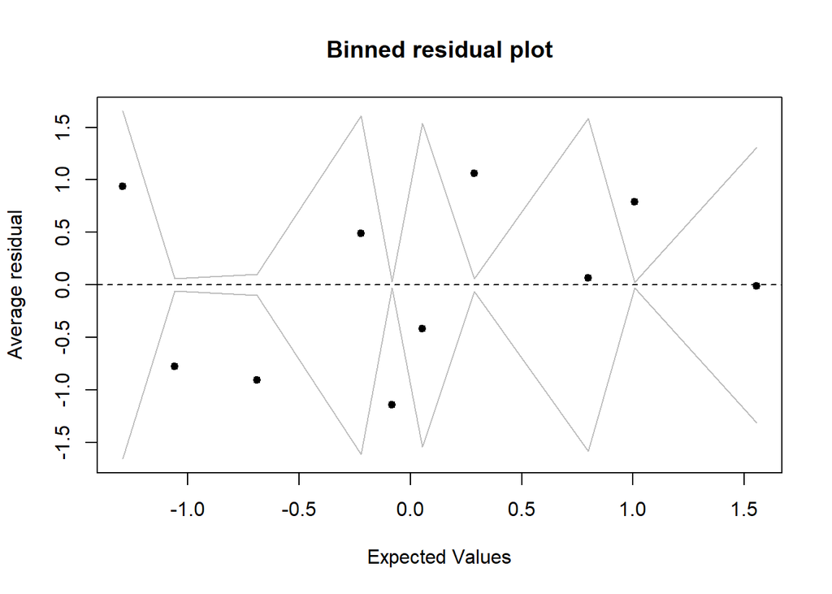

```r
x <- predict(fit.4)
y <- resid(fit.4)
binnedplot(x, y)
```

```r
coef(fit.4)
```

```
##           (Intercept) Body_Condition_Factor
##             -8.794705             11.438501
```

```r
confint(fit.4)
```

```
##                            2.5 %    97.5 %
## (Intercept)           -18.319710 -1.058042
## Body_Condition_Factor   1.490894 23.737218
```

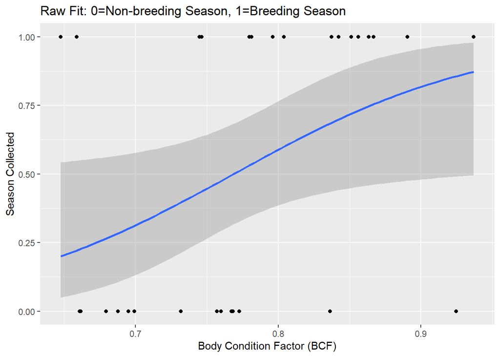

```r
ggplot(Season_BCF, aes(Body_Condition_Factor,Season_Collected)) +
  geom_point() +
  geom_smooth(method="glm", method.args=list(family="binomial"(link="logit"))) +
  xlab ("Body Condition Factor (BCF)") +
  ylab ("Season Collected") +
  labs (title="Raw Fit: 0=Non-breeding Season, 1=Breeding Season")
```

```r
invlogit <- function(x) {1 / ( 1+exp(-x) ) }
invlogit(coef(fit.4))
```

```
##           (Intercept) Body_Condition_Factor
##          0.0001515103          0.9999892275
```

#The R output for the boxcox() function plots the maximum likelihood surface (the curve) together with a maximum likelihood-based 95% CI (Hector, 2015)

#Helpful GLM component info from Hector, 2015 Ch8

#GLMs have three components: # 1.) a linear predictor- is what comes after the tilde (~) in our linear model formula # 2.) a variance function - models the variation in the data;make use of a much wider rangefamily of distributions including the poisson, the binomial, and the gamma. #3.) a link function- plays a role equivalent to the transformation in normal least squares models. However, rather than transforming the data we transform the predictions made by the linear predictor. Commonly used link functions include the log, square root, and logistic.

```r
Season_BCF <- read.csv("Season_BCF.csv")
```

```r
sex <- read.csv("sex.csv")
```

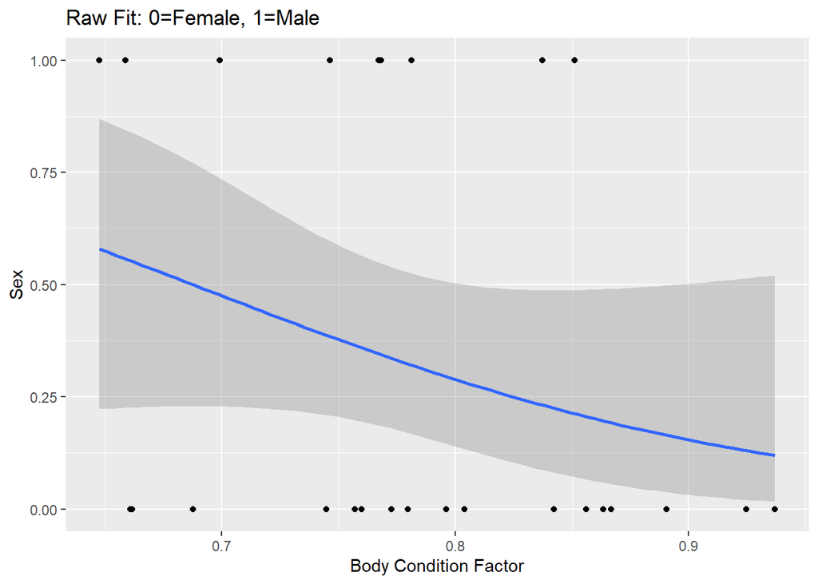

```r
ggplot(sex, aes(Body_Condition_Factor, Sex)) +
  geom_point() +
  geom_smooth(method="glm", method.args=list(family="binomial"(link="logit"))) +
  xlab ("Body Condition Factor") +
  ylab ("Sex") +
  labs (title="Raw Fit: 0=Female, 1=Male")
```

```r
fit.5 <- glm(Sex~Body_Condition_Factor, data=sex, binomial(link="logit"))
```

```r
anova(fit.5)
```

```
## Analysis of Deviance Table
##
## Model: binomial, link: logit
##
## Response: Sex
##
## Terms added sequentially (first to last)
##
##
##                       Df Deviance Resid. Df Resid. Dev
## NULL                                     26     34.372
## Body_Condition_Factor  1   2.1842        25     32.188
```

```r
summary(fit.5)
```

```
##
## Call:
## glm(formula = Sex ~ Body_Condition_Factor, family = binomial(link = "logit"),
##     data = sex)
##
## Deviance Residuals:
##     Min       1Q   Median       3Q      Max
## -1.2694  -0.9239  -0.6616   1.1494   1.7603
##
## Coefficients:
##                       Estimate Std. Error z value Pr(>|z|)
## (Intercept)              5.508      4.394   1.254     0.21
## Body_Condition_Factor   -8.011      5.705  -1.404     0.16
##
## (Dispersion parameter for binomial family taken to be 1)
##
##     Null deviance: 34.372  on 26  degrees of freedom
## Residual deviance: 32.188  on 25  degrees of freedom
## AIC: 36.188
##
## Number of Fisher Scoring iterations: 4
```

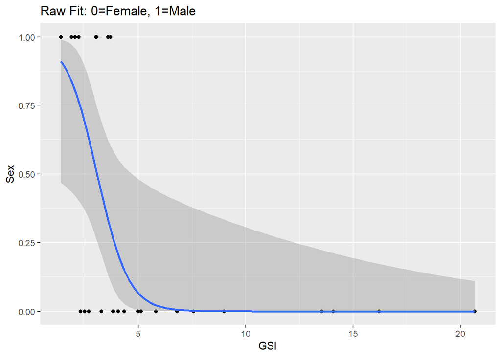

```r
ggplot(sex, aes(GSI_Value, Sex)) +
  geom_point() +
  geom_smooth(method="glm", method.args=list(family="binomial"(link="logit"))) +
  xlab ("GSI") +
  ylab ("Sex") +
  labs (title="Raw Fit: 0=Female, 1=Male")
```

```r
fit.6 <- glm(Sex~GSI_Value, data=sex, binomial(link="logit"))
```

```r
anova(fit.6)
```

```
## Analysis of Deviance Table
##
## Model: binomial, link: logit
##
## Response: Sex
##
## Terms added sequentially (first to last)
##
##
##           Df Deviance Resid. Df Resid. Dev
## NULL                         26     34.372
## GSI_Value  1   13.743        25     20.629
```

```r
summary(fit.6)
```

```
##
## Call:
## glm(formula = Sex ~ GSI_Value, family = binomial(link = "logit"),
##     data = sex)
##
## Deviance Residuals:
##      Min        1Q    Median        3Q       Max
## -1.64909  -0.62058  -0.02353   0.62508   1.55703
##
## Coefficients:
##             Estimate Std. Error z value Pr(>|z|)
## (Intercept)   4.2567     2.1028   2.024   0.0429 *
## GSI_Value    -1.3854     0.6478  -2.139   0.0325 *
## ---
## Signif. codes:  0 '***' 0.001 '**' 0.01 '*' 0.05 '.' 0.1 ' ' 1
##
## (Dispersion parameter for binomial family taken to be 1)
##
##     Null deviance: 34.372  on 26  degrees of freedom
## Residual deviance: 20.629  on 25  degrees of freedom
## AIC: 24.629
##
## Number of Fisher Scoring iterations: 7
```

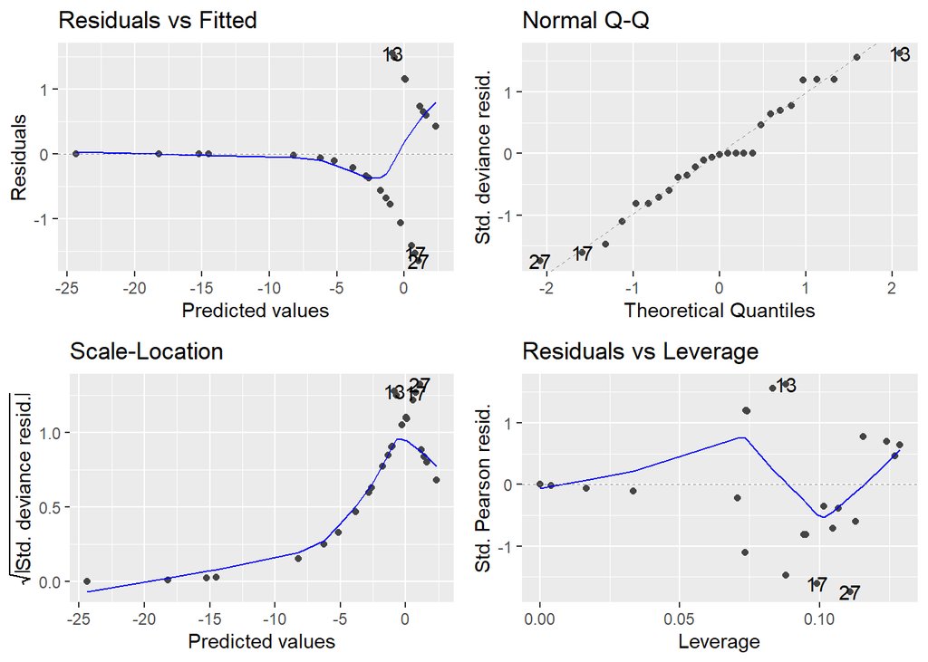

```r
autoplot(fit.6)
```

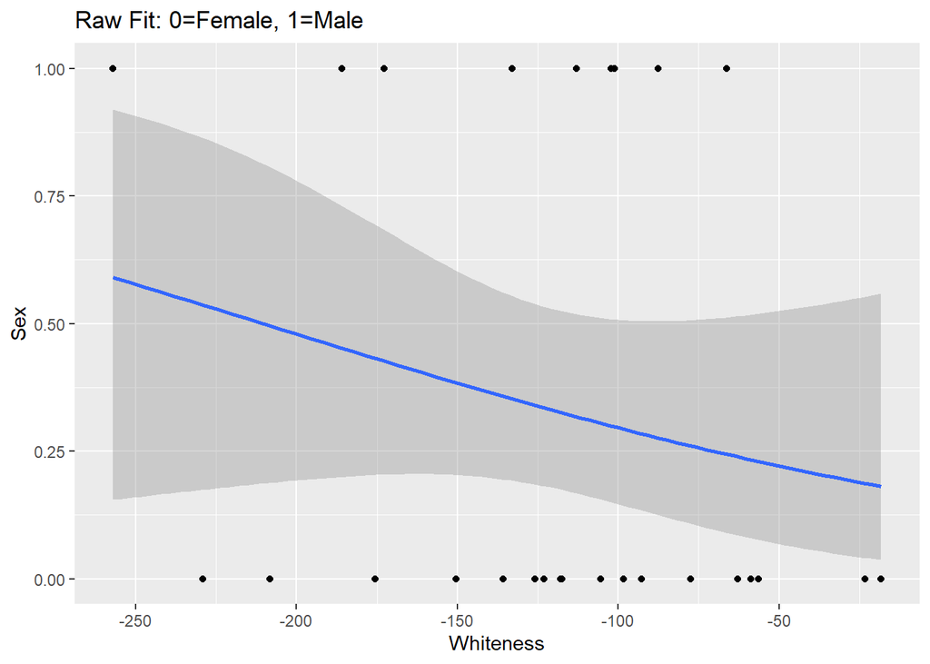

```r
ggplot(sex, aes(Whiteness_Gill,Sex)) +
  geom_point() +
  geom_smooth(method="glm", method.args=list(family="binomial"(link="logit"))) +
  xlab ("Whiteness") +
  ylab ("Sex") +
  labs (title="Raw Fit: 0=Female, 1=Male")
```

```r
fit.7 <- glm(Sex~Whiteness_Gill, data=sex, binomial(link="logit"))
```

```r
anova(fit.7)
```

```
## Analysis of Deviance Table
##
## Model: binomial, link: logit
##
## Response: Sex
##
## Terms added sequentially (first to last)
##
##
##                Df Deviance Resid. Df Resid. Dev
## NULL                              26     34.372
## Whiteness_Gill  1   1.1937        25     33.178
```

```r
summary(fit.7)
```

```
##
## Call:
## glm(formula = Sex ~ Whiteness_Gill, family = binomial(link = "logit"),
##     data = sex)
##
## Deviance Residuals:
##     Min       1Q   Median       3Q      Max
## -1.2398  -0.8955  -0.7389   1.2831   1.6799
##
## Coefficients:
##                 Estimate Std. Error z value Pr(>|z|)
## (Intercept)    -1.651433   1.009484  -1.636    0.102
## Whiteness_Gill -0.007844   0.007331  -1.070    0.285
##
## (Dispersion parameter for binomial family taken to be 1)
##
##     Null deviance: 34.372  on 26  degrees of freedom
## Residual deviance: 33.178  on 25  degrees of freedom
## AIC: 37.178
##
## Number of Fisher Scoring iterations: 4
```

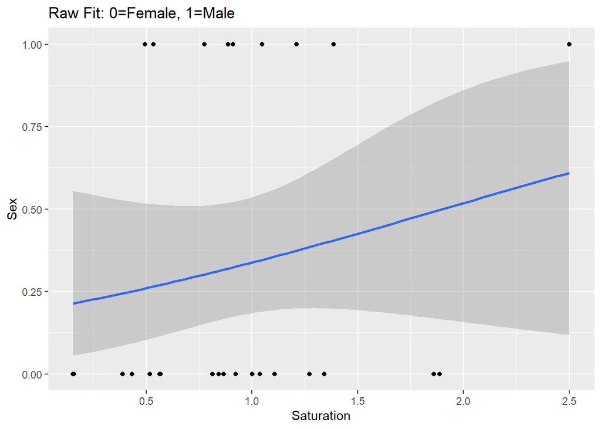

```r
ggplot(sex, aes(Sat_Gill,Sex)) +
  geom_point() +
  geom_smooth(method="glm", method.args=list(family="binomial"(link="logit"))) +
  xlab ("Saturation") +
  ylab ("Sex") +
  labs (title="Raw Fit: 0=Female, 1=Male")
```

```r
fit.8 <- glm(Sex~Sat_Gill, data=sex, binomial(link="logit"))
```

```r
anova(fit.8)
```

```
## Analysis of Deviance Table
##
## Model: binomial, link: logit
##
## Response: Sex
##
## Terms added sequentially (first to last)
##
##
##          Df Deviance Resid. Df Resid. Dev
## NULL                        26     34.372
## Sat_Gill  1  0.93145        25     33.440
```

```r
summary(fit.8)
```

```
##
## Call:
## glm(formula = Sex ~ Sat_Gill, family = binomial(link = "logit"),
##     data = sex)
##
## Deviance Residuals:
##     Min       1Q   Median       3Q      Max
## -1.1729  -0.8980  -0.7807   1.3735   1.6428
##
## Coefficients:
##             Estimate Std. Error z value Pr(>|z|)
## (Intercept)  -1.4172     0.8827  -1.605    0.108
## Sat_Gill      0.7451     0.7843   0.950    0.342
##
## (Dispersion parameter for binomial family taken to be 1)
##
##     Null deviance: 34.372  on 26  degrees of freedom
## Residual deviance: 33.440  on 25  degrees of freedom
## AIC: 37.44
##
## Number of Fisher Scoring iterations: 4
```

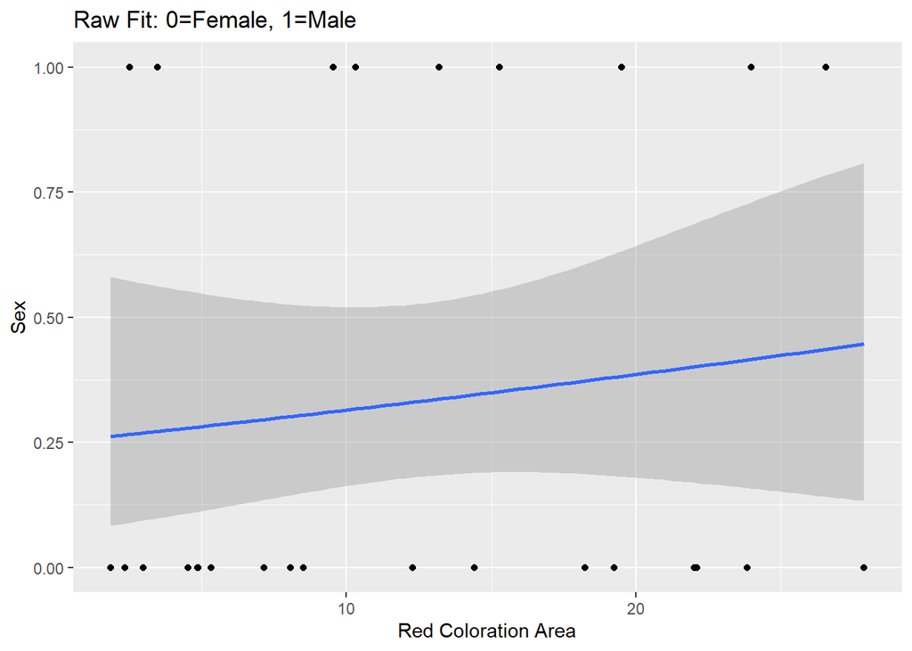

```r
ggplot(sex, aes(Red_Coloration_Area,Sex)) +
  geom_point() +
  geom_smooth(method="glm", method.args=list(family="binomial"(link="logit"))) +
  xlab ("Red Coloration Area") +
  ylab ("Sex") +
  labs (title="Raw Fit: 0=Female, 1=Male")
```

```r
fit.9 <- glm(Sex~Red_Coloration_Area, data=sex, binomial(link="logit"))
```

```r
anova(fit.9)
```

```
## Analysis of Deviance Table
##
## Model: binomial, link: logit
##
## Response: Sex
##
## Terms added sequentially (first to last)
##
##
##                     Df Deviance Resid. Df Resid. Dev
## NULL                                   26     34.372
## Red_Coloration_Area  1  0.40118        25     33.971
```

```r
summary(fit.9)
```

```
##
## Call:
## glm(formula = Sex ~ Red_Coloration_Area, family = binomial(link = "logit"),
##     data = sex)
##
## Deviance Residuals:
##     Min       1Q   Median       3Q      Max
## -1.0867  -0.9077  -0.8116   1.3558   1.6275
##
## Coefficients:
##                     Estimate Std. Error z value Pr(>|z|)
## (Intercept)         -1.09385    0.76958  -1.421    0.155
## Red_Coloration_Area  0.03143    0.04975   0.632    0.527
##
## (Dispersion parameter for binomial family taken to be 1)
##
##     Null deviance: 34.372  on 26  degrees of freedom
## Residual deviance: 33.971  on 25  degrees of freedom
## AIC: 37.971
##
## Number of Fisher Scoring iterations: 4
```

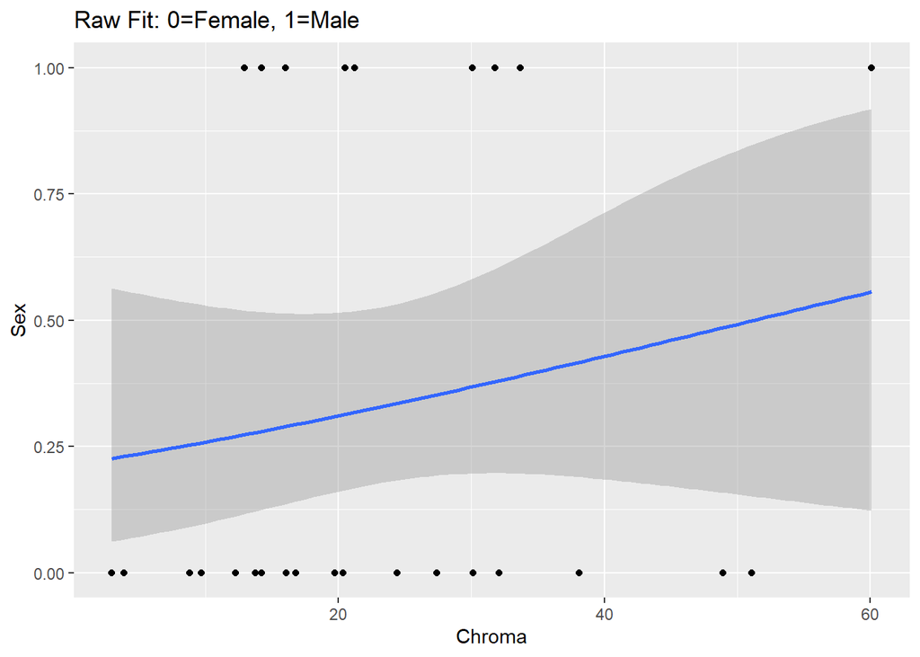

```r
ggplot(sex, aes(Chroma_Gill,Sex)) +
  geom_point() +
  geom_smooth(method="glm", method.args=list(family="binomial"(link="logit"))) +
  xlab ("Chroma") +
  ylab ("Sex") +
  labs (title="Raw Fit: 0=Female, 1=Male")
```

```r
fit.10 <- glm(Sex~Chroma_Gill, data=sex, binomial(link="logit"))
```

```r
anova(fit.10)
```

```
## Analysis of Deviance Table
##
## Model: binomial, link: logit
##
## Response: Sex
##
## Terms added sequentially (first to last)
##
##
##             Df Deviance Resid. Df Resid. Dev
## NULL                           26     34.372
## Chroma_Gill  1  0.77017        25     33.602
```

```r
summary(fit.10)
```

```
##
## Call:
## glm(formula = Sex ~ Chroma_Gill, family = binomial(link = "logit"),
##     data = sex)
##
## Deviance Residuals:
##     Min       1Q   Median       3Q      Max
## -1.1750  -0.8845  -0.7934   1.3836   1.6103
##
## Coefficients:
##             Estimate Std. Error z value Pr(>|z|)
## (Intercept) -1.30702    0.83211  -1.571    0.116
## Chroma_Gill  0.02548    0.02924   0.871    0.384
##
## (Dispersion parameter for binomial family taken to be 1)
##
##     Null deviance: 34.372  on 26  degrees of freedom
## Residual deviance: 33.602  on 25  degrees of freedom
## AIC: 37.602
##
## Number of Fisher Scoring iterations: 4
```

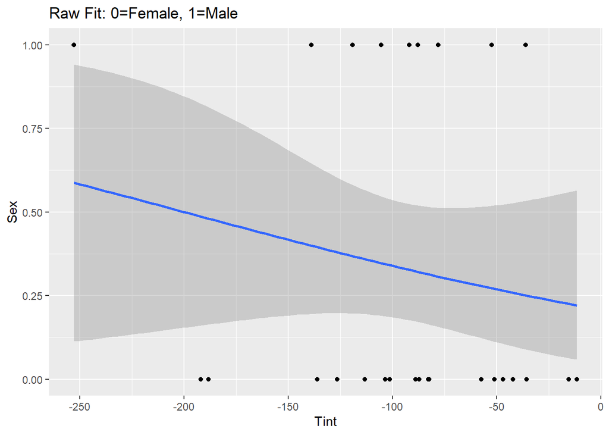

```r
ggplot(sex, aes(Tint_Gill,Sex)) +
  geom_point() +
  geom_smooth(method="glm", method.args=list(family="binomial"(link="logit"))) +
  xlab ("Tint") +
  ylab ("Sex") +
  labs (title="Raw Fit: 0=Female, 1=Male")
```

```r
fit.11 <- glm(Sex~Tint_Gill, data=sex, binomial(link="logit"))
```

```r
anova(fit.11)
```

```
## Analysis of Deviance Table
##
## Model: binomial, link: logit
##
## Response: Sex
##
## Terms added sequentially (first to last)
##
##
##           Df Deviance Resid. Df Resid. Dev
## NULL                         26     34.372
## Tint_Gill  1  0.80716        25     33.565
```

```r
summary(fit.11)
```

```
##
## Call:
## glm(formula = Sex ~ Tint_Gill, family = binomial(link = "logit"),
##     data = sex)
##
## Deviance Residuals:
##     Min       1Q   Median       3Q      Max
## -1.1548  -0.8975  -0.7839   1.3845   1.6635
##
## Coefficients:
##              Estimate Std. Error z value Pr(>|z|)
## (Intercept) -1.336593   0.849369  -1.574    0.116
## Tint_Gill   -0.006685   0.007530  -0.888    0.375
##
## (Dispersion parameter for binomial family taken to be 1)
##
##     Null deviance: 34.372  on 26  degrees of freedom
## Residual deviance: 33.565  on 25  degrees of freedom
## AIC: 37.565
##
## Number of Fisher Scoring iterations: 4
```

```r
fit.12 <- glm(Sex~DominantWavelength_Gill_nm, data=sex, binomial(link="logit"))
```

```r
anova(fit.12)
```

```
## Analysis of Deviance Table
##
## Model: binomial, link: logit
##
## Response: Sex
##
## Terms added sequentially (first to last)
##
##
##                            Df Deviance Resid. Df Resid. Dev
## NULL                                          26     34.372
## DominantWavelength_Gill_nm  1  0.01331        25     34.358
```

```r
summary(fit.12)
```

```
##
## Call:
## glm(formula = Sex ~ DominantWavelength_Gill_nm, family = binomial(link = "logit"),
##     data = sex)
##
## Deviance Residuals:
##     Min       1Q   Median       3Q      Max
## -0.9232  -0.9097  -0.8894   1.4700   1.5377
##
## Coefficients:
##                            Estimate Std. Error z value Pr(>|z|)
## (Intercept)                -7.12970   55.96033  -0.127    0.899
## DominantWavelength_Gill_nm  0.01082    0.09408   0.115    0.908
##
## (Dispersion parameter for binomial family taken to be 1)
##
##     Null deviance: 34.372  on 26  degrees of freedom
## Residual deviance: 34.358  on 25  degrees of freedom
## AIC: 38.358
##
## Number of Fisher Scoring iterations: 4
```

NOTE 9 MALES VS. 18 FEMALES SEXED

Binary Data: Season

```r
season <- read.csv("season.csv")
```

```r
season_whiteness <- glm(Season_Collected~Whiteness_Gill, data=season, binomial(link="logit"))

anova(season_whiteness)
```

```
## Analysis of Deviance Table
##
## Model: binomial, link: logit
##
## Response: Season_Collected
##
## Terms added sequentially (first to last)
##
##
##                Df Deviance Resid. Df Resid. Dev
## NULL                              30     42.943
## Whiteness_Gill  1    5.472        29     37.471
```

```r
summary(season_whiteness)
```

```
##
## Call:
## glm(formula = Season_Collected ~ Whiteness_Gill, family = binomial(link = "logit"),
##     data = season)
##
## Deviance Residuals:
##     Min       1Q   Median       3Q      Max
## -1.5771  -1.0992   0.3923   1.0637   1.6442
##
## Coefficients:
##                 Estimate Std. Error z value Pr(>|z|)
## (Intercept)    -2.057820   1.093577  -1.882   0.0599 .
## Whiteness_Gill -0.017829   0.008743  -2.039   0.0414 *
## ---
## Signif. codes:  0 '***' 0.001 '**' 0.01 '*' 0.05 '.' 0.1 ' ' 1
##
## (Dispersion parameter for binomial family taken to be 1)
##
##     Null deviance: 42.943  on 30  degrees of freedom
## Residual deviance: 37.471  on 29  degrees of freedom
## AIC: 41.471
##
## Number of Fisher Scoring iterations: 3
```

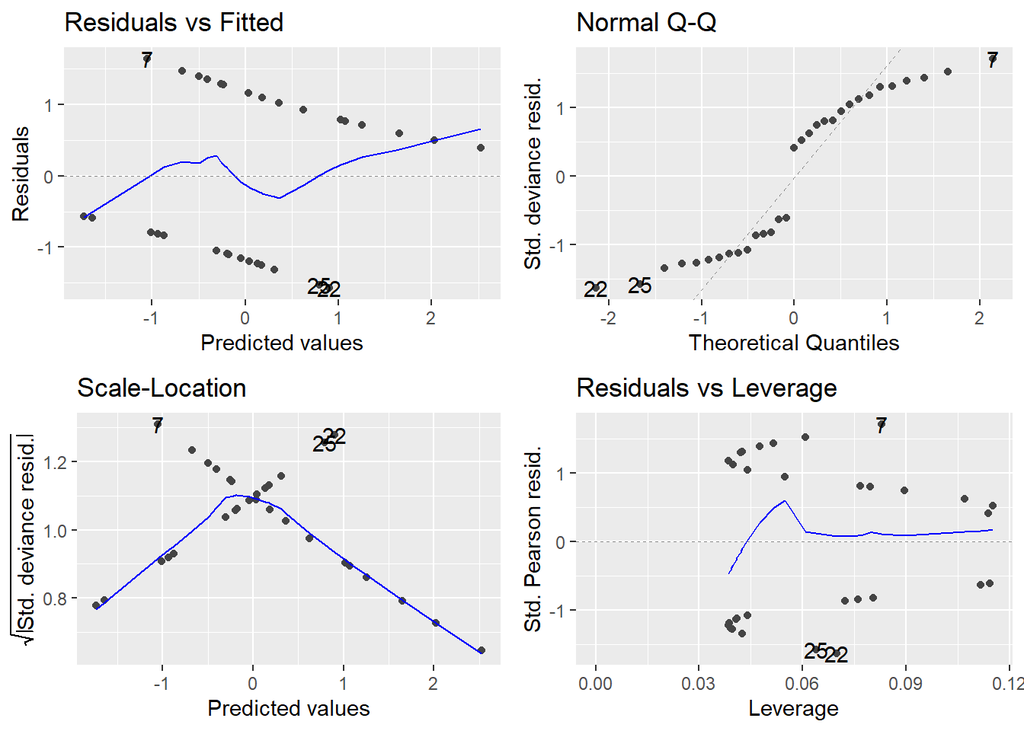

```r
autoplot(season_whiteness)
```

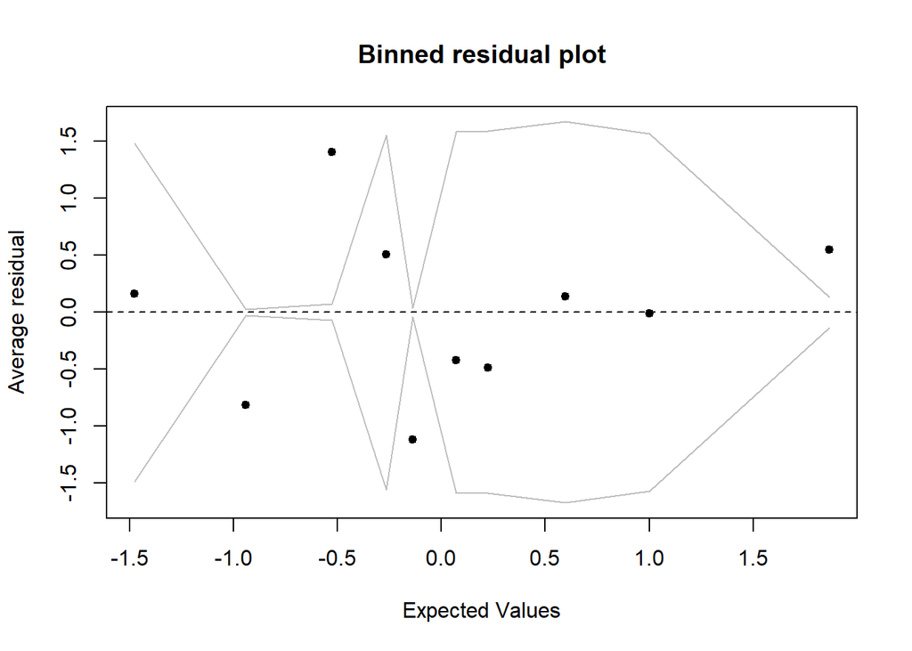

```r
x <- predict(season_whiteness)
y <- resid(season_whiteness)
binnedplot(x, y)
```

```r
coef(season_whiteness)
```

```
##    (Intercept) Whiteness_Gill
##    -2.05782012    -0.01782885
```

```r
confint(season_whiteness)
```

```
##                      2.5 %       97.5 %
## (Intercept)    -4.51622094 -0.109849268
## Whiteness_Gill -0.03791468 -0.002640105
```

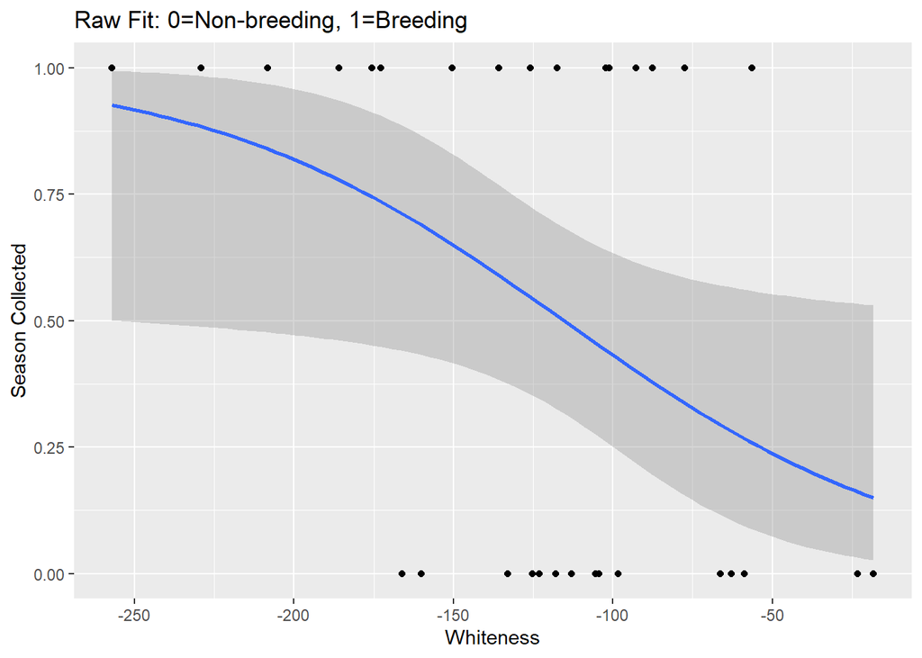

```r
ggplot(season, aes(Whiteness_Gill, Season_Collected)) +
  geom_point() +
  geom_smooth(method="glm", method.args=list(family="binomial"(link="logit"))) +
  xlab ("Whiteness") +
  ylab ("Season Collected") +
  labs (title="Raw Fit: 0=Non-breeding, 1=Breeding")
```

```r
season_sat <- glm(Season_Collected~Sat_Gill, data=season, binomial(link="logit"))

anova(season_sat)
```

```
## Analysis of Deviance Table
##
## Model: binomial, link: logit
##
## Response: Season_Collected
##
## Terms added sequentially (first to last)
##
##
##          Df Deviance Resid. Df Resid. Dev
## NULL                        30     42.943
## Sat_Gill  1   3.8451        29     39.098
```

```r
summary(season_sat)
```

```
##
## Call:
## glm(formula = Season_Collected ~ Sat_Gill, family = binomial(link = "logit"),
##     data = season)
##
## Deviance Residuals:
##     Min       1Q   Median       3Q      Max
## -1.6740  -1.1352   0.3925   1.0697   1.5099
##
## Coefficients:
##             Estimate Std. Error z value Pr(>|z|)
## (Intercept)  -1.4410     0.9208  -1.565    0.118
## Sat_Gill      1.5858     0.9089   1.745    0.081 .
## ---
## Signif. codes:  0 '***' 0.001 '**' 0.01 '*' 0.05 '.' 0.1 ' ' 1
##
## (Dispersion parameter for binomial family taken to be 1)
##
##     Null deviance: 42.943  on 30  degrees of freedom
## Residual deviance: 39.098  on 29  degrees of freedom
## AIC: 43.098
##
## Number of Fisher Scoring iterations: 3
```

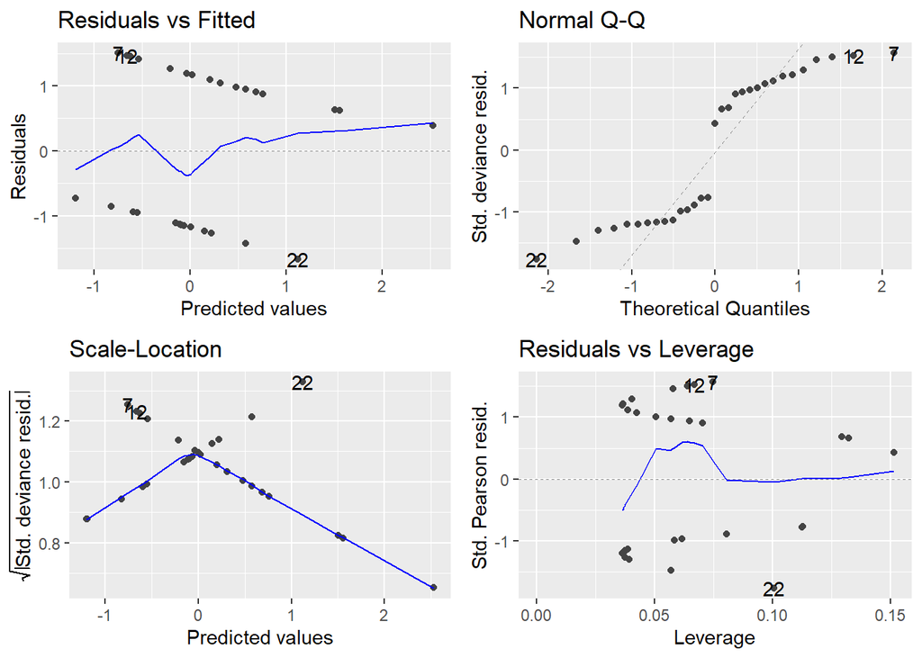

```r
autoplot(season_sat)
```

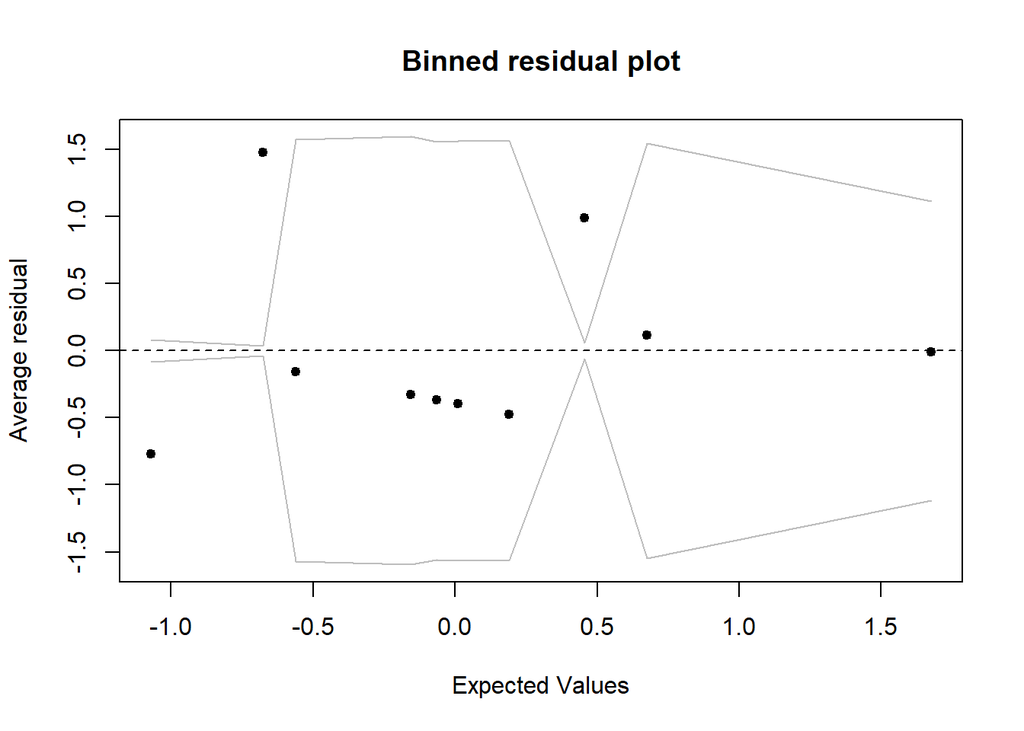

```r
x <- predict(season_sat)
y <- resid(season_sat)
binnedplot(x, y)
```

```r
coef(season_sat)
```

```
## (Intercept)    Sat_Gill
##   -1.441022    1.585776
```

```r
confint(season_sat)
```

```
##                     2.5 %    97.5 %
## (Intercept) -3.4742170007 0.2307588
## Sat_Gill     0.0008186747 3.6562478
```

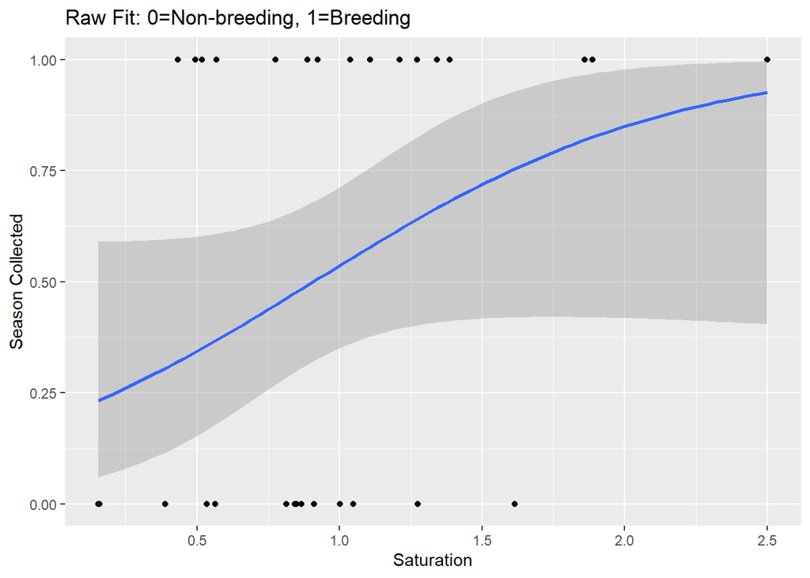

```r
ggplot(season, aes(Sat_Gill, Season_Collected)) +
  geom_point() +
  geom_smooth(method="glm", method.args=list(family="binomial"(link="logit"))) +
  xlab ("Saturation") +
  ylab ("Season Collected") +
  labs (title="Raw Fit: 0=Non-breeding, 1=Breeding")
```

```r
season_chroma <- glm(Season_Collected~Chroma_Gill, data=season, binomial(link="logit"))

anova(season_chroma)
```

```
## Analysis of Deviance Table
##
## Model: binomial, link: logit
##
## Response: Season_Collected
##
## Terms added sequentially (first to last)
##
##
##             Df Deviance Resid. Df Resid. Dev
## NULL                           30     42.943
## Chroma_Gill  1   9.2716        29     33.671
```

```r
summary(season_chroma)
```

```
##
## Call:
## glm(formula = Season_Collected ~ Chroma_Gill, family = binomial(link = "logit"),
##     data = season)
##
## Deviance Residuals:
##     Min       1Q   Median       3Q      Max
## -1.7268  -0.9334   0.1642   0.8161   1.7843
##
## Coefficients:
##             Estimate Std. Error z value Pr(>|z|)
## (Intercept) -2.45349    1.08376  -2.264   0.0236 *
## Chroma_Gill  0.11231    0.04692   2.394   0.0167 *
## ---
## Signif. codes:  0 '***' 0.001 '**' 0.01 '*' 0.05 '.' 0.1 ' ' 1
##
## (Dispersion parameter for binomial family taken to be 1)
##
##     Null deviance: 42.943  on 30  degrees of freedom
## Residual deviance: 33.671  on 29  degrees of freedom
## AIC: 37.671
##
## Number of Fisher Scoring iterations: 5
```

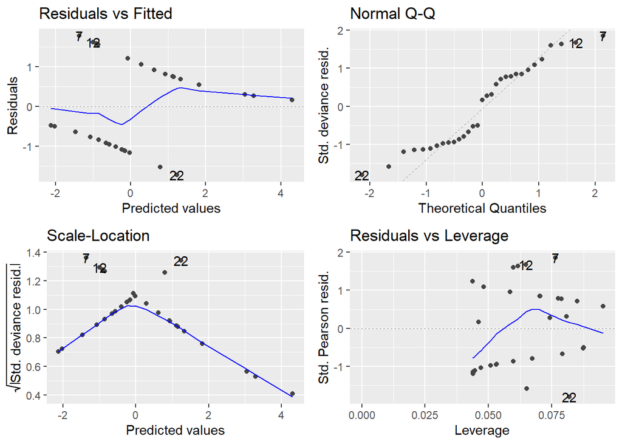

```r
autoplot(season_chroma)
```

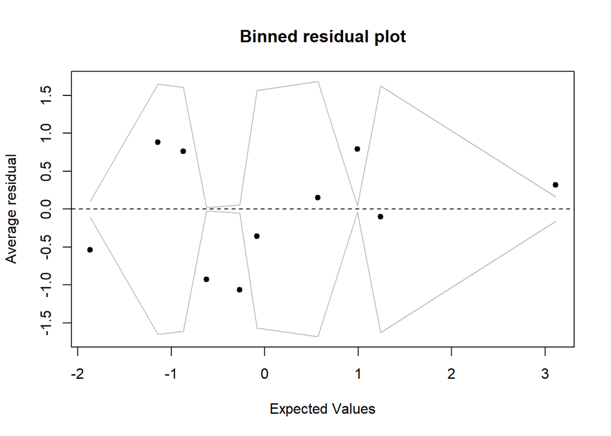

```r
x <- predict(season_chroma)
y <- resid(season_chroma)
binnedplot(x, y)
```

```r
coef(season_chroma)
```

```
## (Intercept) Chroma_Gill
##  -2.4534932   0.1123059
```

```r
confint(season_chroma)
```

```
##                   2.5 %     97.5 %
## (Intercept) -4.91273947 -0.5739551
## Chroma_Gill  0.03436441  0.2213027
```

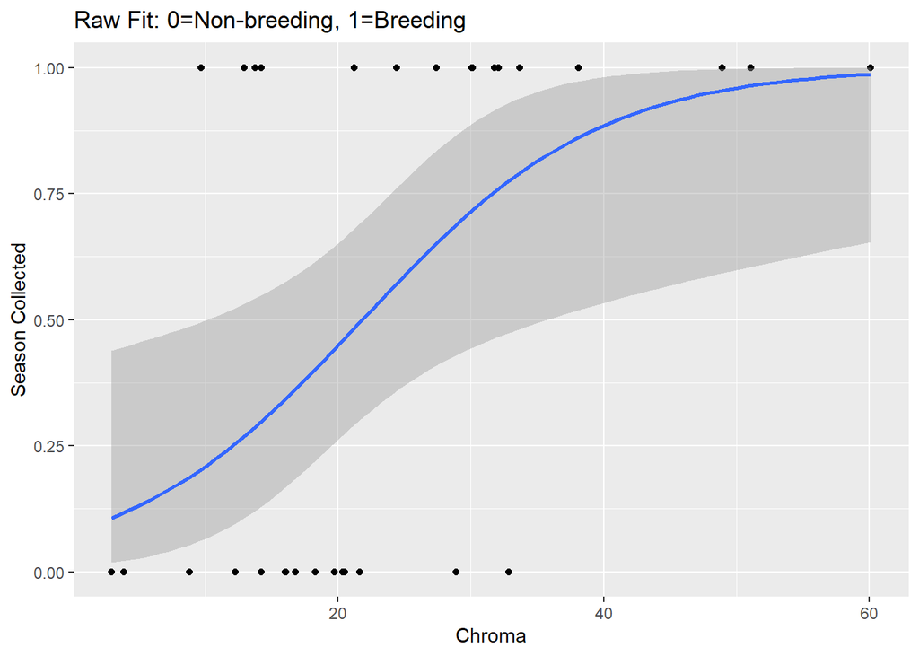

```r
ggplot(season, aes(Chroma_Gill, Season_Collected)) +
  geom_point() +
  geom_smooth(method="glm", method.args=list(family="binomial"(link="logit"))) +
  xlab ("Chroma") +
  ylab ("Season Collected") +
  labs (title="Raw Fit: 0=Non-breeding, 1=Breeding")
```

```r
season_tint <- glm(Season_Collected~Tint_Gill, data=season, binomial(link="logit"))

anova(season_tint)
```

```
## Analysis of Deviance Table
##
## Model: binomial, link: logit
##
## Response: Season_Collected
##
## Terms added sequentially (first to last)
##
##
##           Df Deviance Resid. Df Resid. Dev
## NULL                         30     42.943
## Tint_Gill  1   3.3121        29     39.631
```